# SF Strike Meals Allocation: Final Report

## 1 1. Problem Statement

During the SFUSD strike window (Monday, February 9, 2026 and Tuesday, February 10, 2026), community organizations distributed packed meals at fixed locations across San Francisco. The planning question is how to allocate limited meals across sites to better match tract-level child demand (`age < 18`) derived from the most recent Census ACS release.

This report compares:

- `status_quo`: site-day capacities as listed.
- `optimal_reallocation`: same day-total supply, reallocated across open sites using a linear program.

## 2 2. Problem Formulation

### 2.1 1. Scope and Time Horizon

We solve a **single static LP** over two strike days:

- Monday: `2026-02-09`
- Tuesday: `2026-02-10`

Static means both days are optimized jointly in one model run (not sequentially).

### 2.2 2. Sets and Indices

- $I$: demand nodes (SF Census tracts)
- $J$: supply nodes (meal distribution sites)
- $D = \{2026\text{-}02\text{-}09,\ 2026\text{-}02\text{-}10\}$: days
- $M$: meal types (`lunch`, optionally `breakfast`)

### 2.3 3. Inputs (Parameters)

- $s_{j,d,m}$: meals available at site $j$, day $d$, meal type $m$
  - from `data/processed/site_day_supply.csv`
- $p_i$: child population (`age < 18`) in tract $i$
  - from Census API (ACS most recent 5-year release at runtime)
  - current extraction: ACS 2024, SF county tracts
- $r_m$: participation rate for meal type $m$
- $\mathrm{dem}_{i,d,m}$: expected demand, typically $p_i \cdot r_m$
  - current generated input: `data/processed/tract_day_demand.csv`
- $c_{i,j}$: access/transport cost from tract $i$ to site $j$
  - current generated input: `data/processed/tract_site_cost_matrix.csv`
  - metric: haversine straight-line distance in miles ($c_{ij} = \mathrm{distance\_miles}$)
- $\lambda_m$: unmet-demand penalty weight

### 2.4 4. Decision Variables

- $x_{i,j,d,m} \ge 0$: meals of type $m$ allocated from site $j$ to tract $i$ on day $d$
- $u_{i,d,m} \ge 0$: unmet meals of type $m$ in tract $i$ on day $d$

### 2.5 5. Objective

Minimize transport burden and unmet demand across both days:

$$\min \sum_{i,j,d,m} c_{i,j}\,x_{i,j,d,m} \;+\; \sum_{i,d,m} \lambda_m\,u_{i,d,m}$$

### 2.6 6. Constraints

1. Site/day/meal capacity:
   - $\sum_i x_{i,j,d,m} \le s_{j,d,m}$ for all $(j,d,m)$
2. Demand balance:
   - $\sum_j x_{i,j,d,m} + u_{i,d,m} = \mathrm{dem}_{i,d,m}$ for all $(i,d,m)$
3. Non-negativity:
   - $x_{i,j,d,m} \ge 0$, $u_{i,d,m} \ge 0$
4. Optional policy constraints:
   - maximum service radius ($x_{i,j,d,m}=0$ if $c_{i,j}$ exceeds threshold)
   - equity floor by neighborhood

### 2.7 7. Initial Modeling Choice

Baseline run:

- include `lunch` only
- set `M = {lunch}`
- extend to `breakfast` in sensitivity if needed

This keeps the first solve aligned with the largest available capacity block.

Comparison setup used for status-quo vs optimized site allocations:

- `status_quo` model: $\sum_i x_{i,j,d} \le s_{j,d}$ with fixed listed site-day supply.
- `optimal_reallocation` model:
  - introduces $y_{j,d}$ as optimized site-day meals
  - enforces $\sum_i x_{i,j,d} \le y_{j,d}$
  - conserves day-total meals: $\sum_j y_{j,d} = \sum_j s_{j,d}$
  - cap on per-site reallocation: $y_{j,d} \le \alpha \cdot s_{j,d}$ with $\alpha = 2.0$ in baseline run
  - unmet penalty set to $\lambda = 100$.

### 2.8 8. Execution Log

- Fixed planning horizon to Monday/Tuesday (`2026-02-09`, `2026-02-10`).
- Built supply input table (`data/processed/site_day_supply.csv`).
- Built tract-level `p_i` from Census API (`data/processed/tract_child_population.csv`, ACS 2024, 244 tracts).
- Built tract/day demand scenarios (`data/processed/tract_day_demand.csv`, participation rates `0.2, 0.3, 0.4`).
- Defined `c_{i,j}` matrix (`data/processed/tract_site_cost_matrix.csv`, 244x40 pairs).
- Solved baseline comparison LP and exported:
  - `data/processed/allocation_comparison_summary.csv`
  - `data/processed/site_day_allocation_comparison.csv`
  - `outputs/figures/status_quo_vs_optimal_allocations.png`

## 3 3. Empirics

### 3.1 1. Objective

Build a reproducible pipeline to estimate child demand (`age < 18`) across San Francisco and compute an optimal packed-lunch allocation plan during the SFUSD strike week.

Working assumption for this project: **two strike days only, Monday February 9, 2026 and Tuesday February 10, 2026**.

### 3.2 2. Core Data Sources

1. Meal-site supply and schedule:
   - Source: https://www.sf.gov/departments--children-youth-and-their-families/free-youth-meals-sfusd-school-strike
   - Fields needed: site name, address, day, meal type, meals available.
2. Census child population estimates:
   - Source: U.S. Census API (most recent ACS 5-year release available at runtime).
   - Geography target: Census tracts (or block groups if feasible) in San Francisco County (`FIPS 075`).
   - API key policy: key is optional for low-volume use; required above 500 queries/IP/day.
3. Spatial geometry:
   - Source: TIGER/Line tract geometries (or Census cartographic boundary files).
4. Geocoding for supply nodes:
   - Source: U.S. Census Geocoder API (`Public_AR_Current` benchmark).
   - API key: not required for this workflow.

### 3.3 3. Data Engineering Plan

#### 3.3.1 3.1 Meal-site extraction

1. Attempt automated extraction from the SF.gov page table.
2. If blocked by JS/challenge, use a manual CSV fallback:
   - `data/raw/meal_sites_manual.csv`
3. Standardize columns:
   - `site_id, site_name, address, day, meals_available, meal_type`
4. Geocode addresses to lat/lon and QA bad matches.

#### 3.3.2 3.2 Census pull for `age < 18`

1. Use ACS sex-by-age table (`B01001`) and sum all under-18 bins.
2. Pull all SF tracts from API and build:
   - `tract_geoid`
   - `child_pop_u18`
3. Join to tract geometry and compute tract centroids for transport costs.
4. Implementation:
   - `scripts/fetch_census_children.py`
   - output: `data/processed/tract_child_population.csv`

#### 3.3.3 3.3 Demand calibration

1. Convert `child_pop_u18` to expected daily meal demand:
   - `demand_i = child_pop_u18_i * participation_rate`
2. Start with citywide participation-rate scenario grid (e.g., `0.2, 0.3, 0.4`) and refine later.
3. Implementation:
   - `scripts/build_tract_day_demand.py`
   - output: `data/processed/tract_day_demand.csv`

#### 3.3.4 3.4 Spatial inputs for LP

1. Geocode meal-site addresses to point coordinates:
   - `scripts/geocode_supply_sites.py`
   - output: `data/processed/site_locations.csv`
2. Build SF tract centroids from TIGER polygons with GeoPandas:
   - `scripts/build_tract_centroids.py`
   - output: `data/processed/tract_centroids.csv`
3. Build tract-to-site cost matrix (`c_{i,j}`) using haversine distance (miles):
   - `scripts/build_tract_site_cost_matrix.py`
   - output: `data/processed/tract_site_cost_matrix.csv`

### 3.4 4. Optimization Formulation (LP)

Let:

- `i` = demand node (tract)
- `j` = supply node (meal site)
- `d in {Mon, Tue}` = strike day (`2026-02-09`, `2026-02-10`)
- `x_{i,j,d} >= 0` = meals allocated from site `j` to tract `i` on day `d`
- `u_{i,d} >= 0` = unmet demand for tract `i` on day `d`
- `c_{i,j}` = transport/access cost (distance or travel time)

Objective:

- Solve a static two-day plan in one LP; minimize total weighted transport cost + unmet demand penalty:
  - `min sum_{i,j,d} c_{i,j} * x_{i,j,d} + lambda * sum_{i,d} u_{i,d}`

Constraints:

1. Site capacity by day:
   - `sum_i x_{i,j,d} <= supply_{j,d}`
2. Demand balance by tract-day:
   - `sum_j x_{i,j,d} + u_{i,d} = demand_{i,d}`
3. Non-negativity:
   - `x_{i,j,d}, u_{i,d} >= 0`
4. Optional policy constraints (if needed):
   - max service radius
   - equity floor by neighborhood
   - site utilization minimums

Modeling note:

- This is a **single static optimization across both days** (not a rolling/day-by-day re-solve).
- Comparison run includes two variants:
  - `status_quo`: site-day meals fixed to listed capacities.
  - `optimal_reallocation`: day-total meals conserved, but reallocated across open sites with per-site cap multiplier.

### 3.5 5. Implementation Steps

1. Create folders and schemas:
   - `data/raw`, `data/processed`, `outputs`, `notebooks`
2. Build ingestion scripts:
   - `scripts/fetch_meal_sites.py`
   - `scripts/fetch_census_children.py`
3. Build optimization script:
   - `scripts/solve_allocation_lp.py`
4. Persist outputs:
   - tract-level demand table
   - site-day allocations (`status_quo` vs `optimal_reallocation`)
   - unmet-demand report
   - map-ready GeoJSON/CSV
5. Add scenario runner:
   - participation-rate and penalty (`lambda`) sensitivity runs.

### 3.6 6. QA and Validation

1. Data QA:
   - no missing geocodes for active sites
   - positive supplies and demands
   - day labels normalized
2. Model QA:
   - capacity constraints never violated
   - total allocated + unmet equals total demand
   - expected behavior under extreme `lambda` values
3. Face-validity checks:
   - high-demand tracts receive higher allocations
   - long-distance assignments decrease when radius caps are used

### 3.7 7. Deliverables

1. Reproducible Quarto report with methods, assumptions, and results.
2. Daily allocation tables by site and tract.
3. Map of demand, supply, and modeled service flows.
4. Sensitivity appendix (participation-rate and penalty scenarios).

### 3.8 8. Open Decisions to Resolve Next

1. Demand-node resolution:
   - tract vs block group.
2. Cost metric:
   - straight-line distance vs travel time.
3. Equity policy:
   - whether to enforce neighborhood minimum coverage.
4. Meal handling:
   - single pooled meal model vs separate breakfast/lunch constraints.

### 3.9 9. Step-by-Step Execution Log (To Fill In)

- Confirm strike-day scope for modeling: Monday 2026-02-09 and Tuesday 2026-02-10.
- Create raw meal-site table from PDF export: `data/raw/meal_sites_manual.csv`.
- Build LP-ready supply table: `data/processed/site_day_supply.csv`.
- Pull ACS child population: `data/processed/tract_child_population.csv` (ACS 2024, 244 tracts).
- Build tract demand table: `data/processed/tract_day_demand.csv` (2 days, scenarios `0.2/0.3/0.4`, lunch baseline).
- Build tract centroids and geocode sites; create `c_{i,j}` matrix (`data/processed/tract_site_cost_matrix.csv`).
- Run baseline LP comparison (`scripts/solve_allocation_lp.py`, `lambda=100`, cap multiplier `2.0`).
- Finalize policy constraints (e.g., fairness floors, service radius, reallocation cap sensitivity).
- Run sensitivity scenarios.
- Produce initial comparison figure: `outputs/figures/status_quo_vs_optimal_allocations.png`.
- Produce final plots/tables/maps.

## 4 4. Results

### 4.1 4.1 Scenario Summary

| Scenario | Participation Rate | Served (Status Quo) | Served (Optimal) | Coverage (Status Quo) | Coverage (Optimal) | Avg Distance Miles (Status Quo) | Avg Distance Miles (Optimal) | Implied Meals Moved |
| --- | --- | --- | --- | --- | --- | --- | --- | --- |
| `pr_0p2` | 0.2 | 3715.0 | 3715.0 | 0.081822 | 0.081822 | 0.157873 | 0.107547 | 1186.8 |
| `pr_0p3` | 0.3 | 3715.0 | 3715.0 | 0.054548 | 0.054548 | 0.142258 | 0.094259 | 1365.0 |
| `pr_0p4` | 0.4 | 3715.0 | 3715.0 | 0.040911 | 0.040911 | 0.139696 | 0.087510 | 1635.6 |

Coverage remains fixed (total supply is fixed), while optimized reallocation lowers average distance and shifts a substantial number of meals across sites.

### 4.2 4.2 Status Quo vs Optimal (Site-Day Scatter)

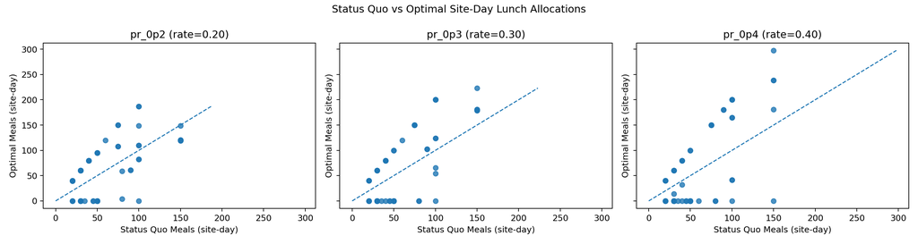

### 4.3 4.3 Site-Level Facet Grid (8 x 5)

Facet titles are `site name + address`. Each panel aggregates each site’s **two-day total lunches** by participation rate and compares status quo vs optimal allocations.

[figure not shown]

## 5 5. Work Log And Directory Structure

### 5.1 5.1 Distilled Work Log

1. Ingested strike meal-site capacities from your SF.gov PDF export and built:
   - `data/raw/meal_sites_manual.csv`
   - `data/processed/site_day_supply.csv`
2. Pulled SF tract child population (`age < 18`) from Census ACS API and built:
   - `data/processed/tract_child_population.csv`
   - `data/processed/tract_day_demand.csv`
3. Built spatial model inputs:
   - geocoded sites via Census geocoder to `data/processed/site_locations.csv`
   - tract centroids via GeoPandas/TIGER to `data/processed/tract_centroids.csv`
   - tract-site distance matrix to `data/processed/tract_site_cost_matrix.csv`
4. Solved and compared allocation models:
   - `data/processed/allocation_comparison_summary.csv`
   - `data/processed/site_day_allocation_comparison.csv`
5. Produced reporting visuals:
   - `outputs/figures/status_quo_vs_optimal_allocations.png`
   - `outputs/figures/site_allocation_facets_8x5.png`

### 5.2 5.2 Key Scripts

- `scripts/extract_meal_sites_from_pdf.py`
- `scripts/build_site_day_supply.py`
- `scripts/fetch_census_children.py`
- `scripts/build_tract_day_demand.py`
- `scripts/geocode_supply_sites.py`
- `scripts/build_tract_centroids.py`
- `scripts/build_tract_site_cost_matrix.py`
- `scripts/solve_allocation_lp.py`
- `scripts/plot_site_facets.py`

### 5.3 5.3 Data Sources

- SF meal-site listing (PDF export from SF.gov strike meals page)
- U.S. Census ACS 5-year API (`B01001` age bins)
- U.S. Census TIGER tract polygons (California, 2024)
- U.S. Census Geocoder API (`Public_AR_Current`)

### 5.4 5.4 Directory Snapshot

```
data/
  raw/
    meal_sites_source.txt
    meal_sites_manual.csv
  processed/
    site_day_supply.csv
    site_locations.csv
    tract_child_population.csv
    tract_day_demand.csv
    tract_centroids.csv
    tract_site_cost_matrix.csv
    allocation_comparison_summary.csv
    site_day_allocation_comparison.csv
outputs/
  figures/
    status_quo_vs_optimal_allocations.png
    site_allocation_facets_8x5.png
scripts/
  extract_meal_sites_from_pdf.py
  build_site_day_supply.py
  fetch_census_children.py
  build_tract_day_demand.py
  geocode_supply_sites.py
  build_tract_centroids.py
  build_tract_site_cost_matrix.py
  solve_allocation_lp.py
  plot_site_facets.py
```